# predict_traffic

### Problem Statement

**Mission**  
You are working with the government to transform your city into a smart city. The vision is to convert it into a digital and intelligent city to improve the efficiency of services for the citizens. One of the problems faced by the government is traffic. You are a data scientist working to manage the traffic of the city better and to provide input on infrastructure planning for the future.

The government wants to implement a robust traffic system for the city by being prepared for traffic peaks. They want to understand the traffic patterns of the four junctions of the city. Traffic patterns on holidays, as well as on various other occasions during the year, differ from normal working days. This is important to take into account for your forecasting.

**Your task**  
To predict traffic patterns in each of these four junctions for the next 4 months.

### Data

The sensors on each of these junctions were collecting data at different times, hence you will see traffic data from different time periods. To add to the complexity, some of the junctions have provided limited or sparse data requiring thoughtfulness when creating future projections. Depending upon the historical data of 20 months, the government is looking to you to *deliver accurate traffic projections for the coming four months*. Your algorithm will become the foundation of a larger transformation to make your city smart and intelligent. (emphasis mine)

The evaluation metric for the competition is RMSE. Public-Private split for the competition is 25:75.

**Data Dictionary**  
*Variable ---- Definition*  
ID ----------- Unique ID  
DateTime ----- Hourly Datetime Variable  
Junction ----- Junction Type  
Vehicles ----- Number of Vehicles (Target)

source: https://datahack.analyticsvidhya.com/contest/mckinsey-analytics-hackathon/

```python
import pandas as pd
import numpy as np

%matplotlib inline
import pandas as pd
import matplotlib.pyplot as plt
import numpy as np

import time
from datetime import datetime
```

```python
df_train = pd.read_csv('/home/datadavis/Desktop/Projects/Mckinsey & Co Data Hackathon/train.csv')
```

```python
df_train.describe()
```

|  | Junction | Vehicles | ID |
| --- | --- | --- | --- |
| count | 48120.000000 | 48120.000000 | 4.812000e+04 |
| mean | 2.180549 | 22.791334 | 2.016330e+10 |
| std | 0.966955 | 20.750063 | 5.944854e+06 |
| min | 1.000000 | 1.000000 | 2.015110e+10 |
| 25% | 1.000000 | 9.000000 | 2.016042e+10 |
| 50% | 2.000000 | 15.000000 | 2.016093e+10 |
| 75% | 3.000000 | 29.000000 | 2.017023e+10 |
| max | 4.000000 | 180.000000 | 2.017063e+10 |

```python
df_train['DateTime'].unique()
```

```
array(['2015-11-01 00:00:00', '2015-11-01 01:00:00', '2015-11-01 02:00:00',
       ..., '2017-06-30 21:00:00', '2017-06-30 22:00:00',
       '2017-06-30 23:00:00'], dtype=object)
```

```python
df_train['Junction'].value_counts()
```

```
3    14592
2    14592
1    14592
4     4344
Name: Junction, dtype: int64
```

```python
time_elem = []

for row in df_train.itertuples():
    time_elem.append(time.strptime(row[1],'%Y-%m-%d %H:%M:%S'))

# https://docs.python.org/3/library/time.html#time.strptime
# https://stackoverflow.com/questions/7837722/what-is-the-most-efficient-way-to-loop-through-dataframes-with-pandas
```

```python
hour_meas = []

for row in df_train.itertuples():
     hour_meas.append(row[5][3])
```

```python
wkday_meas = []

for row in df_train.itertuples():
     wkday_meas.append(row[5][6])
```

```python
df_train['time_elem'] = time_elem
```

```python
df_train['hour_meas'] = hour_meas
```

```python
df_train['wkday_meas'] = wkday_meas
```

```python
df_train.tail(24)
```

|  | DateTime | Junction | Vehicles | ID | time_elem | hour_meas | wkday_meas |
| --- | --- | --- | --- | --- | --- | --- | --- |
| 48096 | 2017-06-30 00:00:00 | 4 | 9 | 20170630004 | (2017, 6, 30, 0, 0, 0, 4, 181, -1) | 0 | 4 |
| 48097 | 2017-06-30 01:00:00 | 4 | 7 | 20170630014 | (2017, 6, 30, 1, 0, 0, 4, 181, -1) | 1 | 4 |
| 48098 | 2017-06-30 02:00:00 | 4 | 5 | 20170630024 | (2017, 6, 30, 2, 0, 0, 4, 181, -1) | 2 | 4 |
| 48099 | 2017-06-30 03:00:00 | 4 | 6 | 20170630034 | (2017, 6, 30, 3, 0, 0, 4, 181, -1) | 3 | 4 |
| 48100 | 2017-06-30 04:00:00 | 4 | 5 | 20170630044 | (2017, 6, 30, 4, 0, 0, 4, 181, -1) | 4 | 4 |
| 48101 | 2017-06-30 05:00:00 | 4 | 5 | 20170630054 | (2017, 6, 30, 5, 0, 0, 4, 181, -1) | 5 | 4 |
| 48102 | 2017-06-30 06:00:00 | 4 | 6 | 20170630064 | (2017, 6, 30, 6, 0, 0, 4, 181, -1) | 6 | 4 |
| 48103 | 2017-06-30 07:00:00 | 4 | 4 | 20170630074 | (2017, 6, 30, 7, 0, 0, 4, 181, -1) | 7 | 4 |
| 48104 | 2017-06-30 08:00:00 | 4 | 5 | 20170630084 | (2017, 6, 30, 8, 0, 0, 4, 181, -1) | 8 | 4 |
| 48105 | 2017-06-30 09:00:00 | 4 | 7 | 20170630094 | (2017, 6, 30, 9, 0, 0, 4, 181, -1) | 9 | 4 |
| 48106 | 2017-06-30 10:00:00 | 4 | 15 | 20170630104 | (2017, 6, 30, 10, 0, 0, 4, 181, -1) | 10 | 4 |
| 48107 | 2017-06-30 11:00:00 | 4 | 14 | 20170630114 | (2017, 6, 30, 11, 0, 0, 4, 181, -1) | 11 | 4 |
| 48108 | 2017-06-30 12:00:00 | 4 | 9 | 20170630124 | (2017, 6, 30, 12, 0, 0, 4, 181, -1) | 12 | 4 |
| 48109 | 2017-06-30 13:00:00 | 4 | 11 | 20170630134 | (2017, 6, 30, 13, 0, 0, 4, 181, -1) | 13 | 4 |
| 48110 | 2017-06-30 14:00:00 | 4 | 10 | 20170630144 | (2017, 6, 30, 14, 0, 0, 4, 181, -1) | 14 | 4 |
| 48111 | 2017-06-30 15:00:00 | 4 | 14 | 20170630154 | (2017, 6, 30, 15, 0, 0, 4, 181, -1) | 15 | 4 |
| 48112 | 2017-06-30 16:00:00 | 4 | 16 | 20170630164 | (2017, 6, 30, 16, 0, 0, 4, 181, -1) | 16 | 4 |
| 48113 | 2017-06-30 17:00:00 | 4 | 16 | 20170630174 | (2017, 6, 30, 17, 0, 0, 4, 181, -1) | 17 | 4 |
| 48114 | 2017-06-30 18:00:00 | 4 | 17 | 20170630184 | (2017, 6, 30, 18, 0, 0, 4, 181, -1) | 18 | 4 |
| 48115 | 2017-06-30 19:00:00 | 4 | 11 | 20170630194 | (2017, 6, 30, 19, 0, 0, 4, 181, -1) | 19 | 4 |
| 48116 | 2017-06-30 20:00:00 | 4 | 30 | 20170630204 | (2017, 6, 30, 20, 0, 0, 4, 181, -1) | 20 | 4 |
| 48117 | 2017-06-30 21:00:00 | 4 | 16 | 20170630214 | (2017, 6, 30, 21, 0, 0, 4, 181, -1) | 21 | 4 |
| 48118 | 2017-06-30 22:00:00 | 4 | 22 | 20170630224 | (2017, 6, 30, 22, 0, 0, 4, 181, -1) | 22 | 4 |
| 48119 | 2017-06-30 23:00:00 | 4 | 12 | 20170630234 | (2017, 6, 30, 23, 0, 0, 4, 181, -1) | 23 | 4 |

### Thought Process

- Calculate daily demand for each junction
- Spread each across the day by cumulative hourly demand (assumption is that each is similarly burdened during day)

```python
t1 = df_train[df_train['Junction'] == 1]
t2 = df_train[df_train['Junction'] == 2]
t3 = df_train[df_train['Junction'] == 3]
t4 = df_train[df_train['Junction'] == 4]
```

```python
t1['Vehicles'].groupby(t1['hour_meas']).mean()

# https://chrisalbon.com/python/pandas_group_rows_by.html
```

```
hour_meas
0     45.738487
1     39.156250
2     33.907895
3     29.430921
4     25.654605
5     24.067434
6     26.080592
7     29.526316
8     32.735197
9     39.003289
10    49.527961
11    56.187500
12    57.254934
13    51.075658
14    54.733553
15    54.218750
16    51.911184
17    51.851974
18    55.411184
19    58.804276
20    57.401316
21    54.537829
22    52.963816
23    50.088816
Name: Vehicles, dtype: float64
```

[output not shown]

[figure not shown]

```python
objects1 = t1['hour_meas'].unique()
y_pos1 = np.arange(len(objects1))
performance1 = t1['Vehicles'].groupby(t1['hour_meas']).mean()

objects2 = t2['hour_meas'].unique()
y_pos2 = np.arange(len(objects2))
performance2 = t2['Vehicles'].groupby(t2['hour_meas']).mean()

objects3 = t3['hour_meas'].unique()
y_pos3 = np.arange(len(objects3))
performance3 = t3['Vehicles'].groupby(t3['hour_meas']).mean()

objects4 = t4['hour_meas'].unique()
y_pos4 = np.arange(len(objects4))
performance4 = t4['Vehicles'].groupby(t4['hour_meas']).mean()
```

[output not shown]

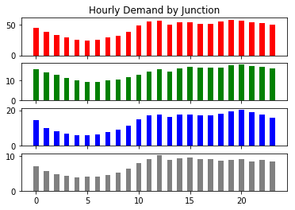

```python
# four subplots, the axes array is 1-d
f, axarr = plt.subplots(4, sharex=True)

axarr[0].set_title('Hourly Demand by Junction')
axarr[0].bar(y_pos1, performance1, 0.5, color='red')
axarr[1].bar(y_pos2, performance2, 0.5, color='green')
axarr[2].bar(y_pos3, performance3, 0.5, color='blue')
axarr[3].bar(y_pos4, performance4, 0.5, color='gray')

# https://matplotlib.org/examples/pylab_examples/subplots_demo.html
# https://pythonspot.com/en/matplotlib-bar-chart/
# https://stackoverflow.com/questions/27678906/4-subplot-barcharts-in-python
```

```python
t1['Vehicles'].groupby(t1['hour_meas']).mean()[0]
```

```
45.73848684210526
```

```python
t1_hr_sum
```

```
1081.2697368421054
```

```python
t1_hr_sum = sum(t1['Vehicles'].groupby(t1['hour_meas']).mean())
t1_hr_weight = []
hr = 0

while hr < 24:
    t1_hr_weight.append(t1['Vehicles'].groupby(t1['hour_meas']).mean()[hr] / t1_hr_sum)
    hr +=1

t1_weights = pd.DataFrame(t1_hr_weight, columns=['wt'])
#t1_weights
```

```python
t2_hr_sum = sum(t2['Vehicles'].groupby(t2['hour_meas']).mean())
t2_hr_weight = []
hr = 0

while hr < 24:
    t2_hr_weight.append(t2['Vehicles'].groupby(t2['hour_meas']).mean()[hr] / t2_hr_sum)
    hr +=1

t2_weights = pd.DataFrame(t2_hr_weight, columns=['wt'])
#t2_weights
```

```python
t3_hr_sum = sum(t3['Vehicles'].groupby(t3['hour_meas']).mean())
t3_hr_weight = []
hr = 0

while hr < 24:
    t3_hr_weight.append(t3['Vehicles'].groupby(t3['hour_meas']).mean()[hr] / t3_hr_sum)
    hr +=1

t3_weights = pd.DataFrame(t3_hr_weight, columns=['wt'])
#t3_weights
```

```python
t4_hr_sum = sum(t4['Vehicles'].groupby(t4['hour_meas']).mean())
t4_hr_weight = []
hr = 0

while hr < 24:
    t4_hr_weight.append(t4['Vehicles'].groupby(t4['hour_meas']).mean()[hr] / t4_hr_sum)
    hr +=1

t4_weights = pd.DataFrame(t4_hr_weight, columns=['wt'])
#t4_weights
```

```python
t4_weights.head()
```

|  | wt |
| --- | --- |
| 0 | 0.039777 |
| 1 | 0.032570 |
| 2 | 0.027809 |
| 3 | 0.024825 |
| 4 | 0.022158 |

## Thought Process

- Now that we have broken down hourly calcs for each junction, it's time to forecast daily data
- We will do this by summarizing the data by day, forecasting with Facebook's Prophet engine, then applying our hourly weights for a best guesstimate of the future

```python
!pip install fbprophet #https://facebook.github.io/prophet/docs/installation.html#installation-in-python
```

```python
from fbprophet import Prophet
```

```python
#mydate = datetime.date(1943,3, 13)

t_date = []

for row in df_train.itertuples():
     t_date.append(datetime(row[5][0], row[5][1], row[5][2]).date())

# http://www.pythonforbeginners.com/basics/python-datetime-time-examples
```

```python
df_train['ds'] = t_date
```

*Go back into the process to recreate the 4 split dataframes with the new column*

```python
t1.head(7)
```

|  | DateTime | Junction | Vehicles | ID | time_elem | hour_meas | wkday_meas | ds |
| --- | --- | --- | --- | --- | --- | --- | --- | --- |
| 0 | 2015-11-01 00:00:00 | 1 | 15 | 20151101001 | (2015, 11, 1, 0, 0, 0, 6, 305, -1) | 0 | 6 | 2015-11-01 |
| 1 | 2015-11-01 01:00:00 | 1 | 13 | 20151101011 | (2015, 11, 1, 1, 0, 0, 6, 305, -1) | 1 | 6 | 2015-11-01 |
| 2 | 2015-11-01 02:00:00 | 1 | 10 | 20151101021 | (2015, 11, 1, 2, 0, 0, 6, 305, -1) | 2 | 6 | 2015-11-01 |
| 3 | 2015-11-01 03:00:00 | 1 | 7 | 20151101031 | (2015, 11, 1, 3, 0, 0, 6, 305, -1) | 3 | 6 | 2015-11-01 |
| 4 | 2015-11-01 04:00:00 | 1 | 9 | 20151101041 | (2015, 11, 1, 4, 0, 0, 6, 305, -1) | 4 | 6 | 2015-11-01 |
| 5 | 2015-11-01 05:00:00 | 1 | 6 | 20151101051 | (2015, 11, 1, 5, 0, 0, 6, 305, -1) | 5 | 6 | 2015-11-01 |
| 6 | 2015-11-01 06:00:00 | 1 | 9 | 20151101061 | (2015, 11, 1, 6, 0, 0, 6, 305, -1) | 6 | 6 | 2015-11-01 |

```
INFO:fbprophet.forecaster:Disabling yearly seasonality. Run prophet with yearly_seasonality=True to override this.
INFO:fbprophet.forecaster:Disabling daily seasonality. Run prophet with daily_seasonality=True to override this.
```

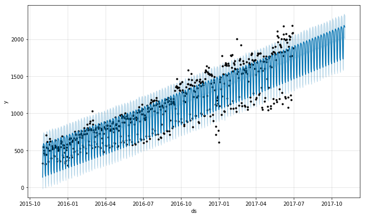

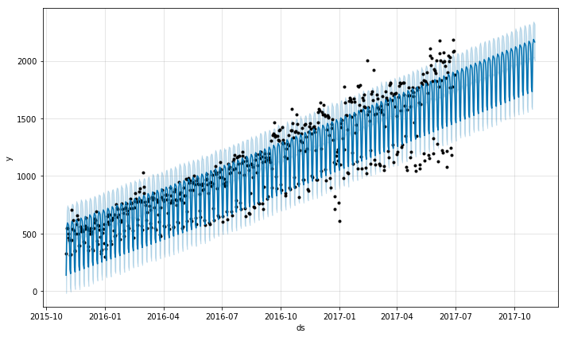

```python
train1 = t1[['ds', 'Vehicles']].groupby(t1['ds']).sum().reset_index()
#train1['Vehicles'] = np.log(train1['Vehicles'])
train1.columns = ['ds', 'y'] # *

m1 = Prophet()
m1.fit(train1)

days_ahead = 4*30 + 5 # 4 months ahead
future1 = m1.make_future_dataframe(periods=days_ahead)
#future.tail()

forecast1 = m1.predict(future1)
#forecast[['ds', 'yhat', 'yhat_lower', 'yhat_upper']].tail()

m1.plot(forecast1)

# https://facebook.github.io/prophet/docs/quick_start.html
# https://stackoverflow.com/questions/11346283/renaming-columns-in-pandas
```

## Thought Process

- Interesting to see the separation in data points over time; I wonder if the other junctions will show a similar pattern
- Makes me think that some days do not include 24 hours worth of data. Let's examine further

```python
t4['hour_meas'].value_counts()
```

```
23    181
19    181
4     181
8     181
12    181
16    181
20    181
1     181
5     181
9     181
13    181
17    181
21    181
2     181
6     181
10    181
14    181
18    181
22    181
3     181
7     181
11    181
15    181
0     181
Name: hour_meas, dtype: int64
```

*There are an equal distribution of samples across the hours for each junction so let's see if the pattern persists for the other forecasts*

```
INFO:fbprophet.forecaster:Disabling yearly seasonality. Run prophet with yearly_seasonality=True to override this.
INFO:fbprophet.forecaster:Disabling daily seasonality. Run prophet with daily_seasonality=True to override this.
```

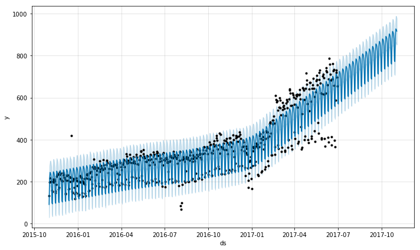

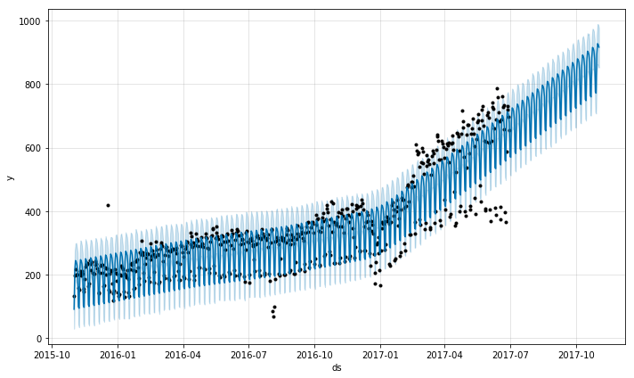

```python
train2 = t2[['ds', 'Vehicles']].groupby(t2['ds']).sum().reset_index()
#train2['Vehicles'] = np.log(train2['Vehicles'])
train2.columns = ['ds', 'y'] # *

m2 = Prophet()
m2.fit(train2)

days_ahead = 4*30 + 5 # 4 months ahead
future2 = m2.make_future_dataframe(periods=days_ahead)
#future.tail()

forecast2 = m2.predict(future2)
#forecast[['ds', 'yhat', 'yhat_lower', 'yhat_upper']].tail()

m2.plot(forecast2)
```

```
INFO:fbprophet.forecaster:Disabling yearly seasonality. Run prophet with yearly_seasonality=True to override this.
INFO:fbprophet.forecaster:Disabling daily seasonality. Run prophet with daily_seasonality=True to override this.
```

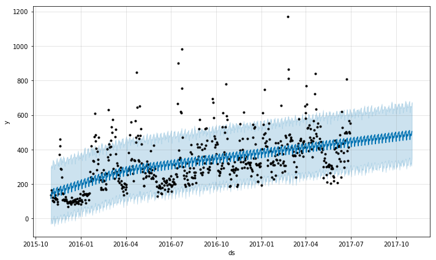

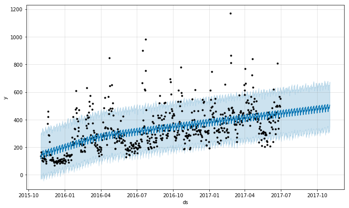

```python
train3 = t3[['ds', 'Vehicles']].groupby(t3['ds']).sum().reset_index()
#train3['Vehicles'] = np.log(train3['Vehicles'])
train3.columns = ['ds', 'y'] # *

m3 = Prophet()
m3.fit(train3)

days_ahead = 4*30 + 5 # 4 months ahead
future3 = m3.make_future_dataframe(periods=days_ahead)
#future.tail()

forecast3 = m3.predict(future3)
#forecast[['ds', 'yhat', 'yhat_lower', 'yhat_upper']].tail()

m3.plot(forecast3)
```

```
INFO:fbprophet.forecaster:Disabling yearly seasonality. Run prophet with yearly_seasonality=True to override this.
INFO:fbprophet.forecaster:Disabling daily seasonality. Run prophet with daily_seasonality=True to override this.
```

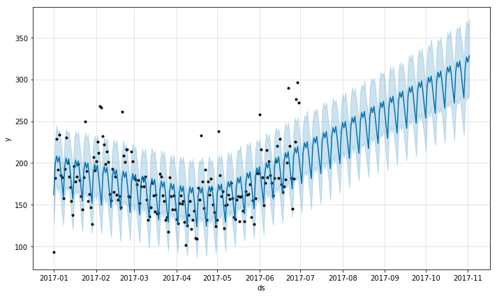

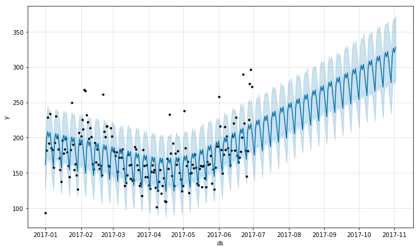

```python
train4 = t4[['ds', 'Vehicles']].groupby(t4['ds']).sum().reset_index()
#train4['Vehicles'] = np.log(train4['Vehicles'])
train4.columns = ['ds', 'y'] # *

m4 = Prophet()
m4.fit(train4)

days_ahead = 4*30 + 5 # 4 months ahead (should count days in test dataset)
future4 = m4.make_future_dataframe(periods=days_ahead)
#future.tail()

forecast4 = m4.predict(future4)
#forecast[['ds', 'yhat', 'yhat_lower', 'yhat_upper']].tail()

m4.plot(forecast4)
```

## Thought Process

- These forecasts would not perform well for the given test of minimizing RMSEs, but appear to be directionally appropriately
- One way to account for this would be to algorithmically grabbing the upper or lower bound vs the average; also could explore impact of day of week
- Let's complete the puzzle by breaking out by hour and mapping to IDs (YYYYMMDDHHJ)

```python
df_test = pd.read_csv('/home/datadavis/Desktop/Projects/Mckinsey & Co Data Hackathon/test.csv')
```

```python
test_id_day = []

for row in df_test.itertuples():
    test_id_day.append(str(row[3])[0:8])

len(pd.Series(test_id_day).unique()) # how many days to project? I used 125 so good to go
```

```
123
```

```python
df_test.head()
```

|  | DateTime | Junction | ID |
| --- | --- | --- | --- |
| 0 | 2017-07-01 00:00:00 | 1 | 20170701001 |
| 1 | 2017-07-01 01:00:00 | 1 | 20170701011 |
| 2 | 2017-07-01 02:00:00 | 1 | 20170701021 |
| 3 | 2017-07-01 03:00:00 | 1 | 20170701031 |
| 4 | 2017-07-01 04:00:00 | 1 | 20170701041 |

```python
forecast4[forecast4['ds'] == '2017-07-02'].head(1)['yhat'].values[0]
```

```
175.11737328546968
```

```python
t4_weights['wt'][0]
```

```
0.039776515031268847
```

```python
# test dynamic dataframe references

#test_case = [1, 2, 3, 4]

#for t in test_case:
#    fc_df = 'm' + str(t)
#    print(fc_df.head(0))

# AttributeError: 'str' object has no attribute 'head'

# https://stackoverflow.com/questions/25486438/how-to-dynamically-refer-to-dataframes-in-a-for-loop-in-python

forecasts = [forecast1, forecast2, forecast3, forecast4]
weights = [t1_weights, t2_weights, t3_weights, t4_weights]
hours = np.arange(24)
est = []

for r in df_test.itertuples():
    ts = time.strptime(r[1],'%Y-%m-%d %H:%M:%S')
    test_date = datetime(ts.tm_year, ts.tm_mon, ts.tm_mday).date()
    test_hour = ts.tm_hour
    junc_index = r[2]
    fc_index = junc_index - 1

    if fc_index == 0:
        day_pred = forecast1[forecast1['ds'] == test_date]['yhat'].values
        hr_wt = t1_weights['wt'][test_hour]
        hr_pred = day_pred * hr_wt

        pred = [r[3]
                , hr_pred[0]
                , datetime(ts.tm_year, ts.tm_mon, ts.tm_mday, test_hour)
                , r[2]] # ID, Vehicles, Timestamp, Junction
        est.append(pred)
    elif fc_index == 1:
        day_pred = forecast2[forecast2['ds'] == test_date]['yhat'].values
        hr_wt = t2_weights['wt'][test_hour]
        hr_pred = day_pred * hr_wt

        pred = [r[3]
                , hr_pred[0]
                , datetime(ts.tm_year, ts.tm_mon, ts.tm_mday, test_hour)
                , r[2]] # ID, Vehicles, Timestamp, Junction
        est.append(pred)
    elif fc_index == 2:
        day_pred = forecast3[forecast3['ds'] == test_date]['yhat'].values
        hr_wt = t3_weights['wt'][test_hour]
        hr_pred = day_pred * hr_wt

        pred = [r[3]
                , hr_pred[0]
                , datetime(ts.tm_year, ts.tm_mon, ts.tm_mday, test_hour)
                , r[2]] # ID, Vehicles, Timestamp, Junction
        est.append(pred)
    elif fc_index == 3:
        day_pred = forecast4[forecast4['ds'] == test_date]['yhat'].values
        hr_wt = t4_weights['wt'][test_hour]
        hr_pred = day_pred * hr_wt

        pred = [r[3]
                , hr_pred[0]
                , datetime(ts.tm_year, ts.tm_mon, ts.tm_mday, test_hour)
                , r[2]] # ID, Vehicles, Timestamp, Junction
        est.append(pred)

res = pd.DataFrame(est, columns=['ID', 'Vehicles', 'Timestamp', 'Junction'])
```

```python
res.head(10)
```

|  | ID | Vehicles | Timestamp | Junction |
| --- | --- | --- | --- | --- |
| 0 | 20170701001 | 63.381396 | 2017-07-01 00:00:00 | 1 |
| 1 | 20170701011 | 54.260164 | 2017-07-01 01:00:00 | 1 |
| 2 | 20170701021 | 46.987337 | 2017-07-01 02:00:00 | 1 |
| 3 | 20170701031 | 40.783441 | 2017-07-01 03:00:00 | 1 |
| 4 | 20170701041 | 35.550470 | 2017-07-01 04:00:00 | 1 |
| 5 | 20170701051 | 33.351072 | 2017-07-01 05:00:00 | 1 |
| 6 | 20170701061 | 36.140774 | 2017-07-01 06:00:00 | 1 |
| 7 | 20170701071 | 40.915632 | 2017-07-01 07:00:00 | 1 |
| 8 | 20170701081 | 45.362290 | 2017-07-01 08:00:00 | 1 |
| 9 | 20170701091 | 54.048201 | 2017-07-01 09:00:00 | 1 |

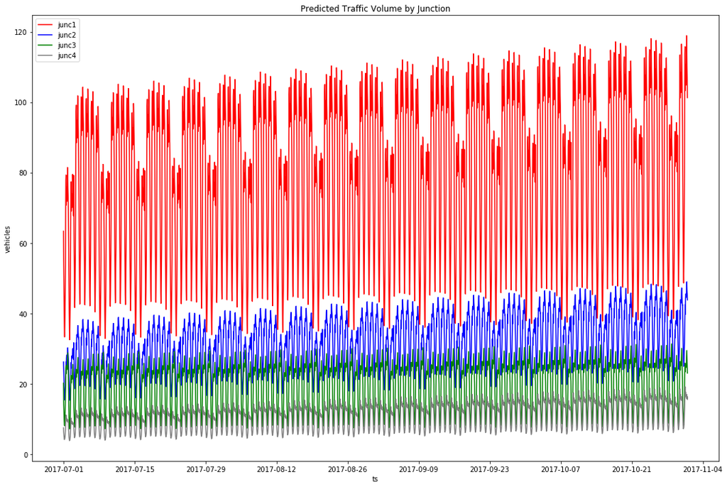

```python
x = res['Timestamp'].unique()
a = res[res['Junction'] == 1]['Vehicles']
b = res[res['Junction'] == 2]['Vehicles']
c = res[res['Junction'] == 3]['Vehicles']
d = res[res['Junction'] == 4]['Vehicles']

fig = plt.figure(figsize=(18, 12))

la = plt.plot(x,a,'r-',label='junc1')
lb = plt.plot(x,b,'b-',label='junc2')
lc = plt.plot(x,c,'g-',label='junc3')
ld = plt.plot(x,d,'gray', label='junc4')
ll = plt.legend(loc='best')

lx = plt.xlabel('ts')
ly = plt.ylabel('vehicles')
lt = plt.title('Predicted Traffic Volume by Junction')

plt.show()

# http://kestrel.nmt.edu/~raymond/software/python_notes/paper004.html
# https://stackoverflow.com/a/22399608/2583997 -- sizing plot
```

```python
res[['ID', 'Vehicles']].to_csv('traffic_predictions.csv', index=False)
```